# Análisis Descriptivo con R

Cristian Santa

# Enunciado

La siguiente base de datos contiene información acerca de incautaciones de bebidas alcohólicas fraudulentas y de contrabando en la ciudad de Medellín en un mes, que afectan los recursos para Salud y Educación en el Departamento de Antioquia y de acuerdo a los resultados se toma decisiones para aumentar o disminuir los controles.

[Licores](https://cdsantae.github.io/BioStat1/_site/R/Licores.xlsx)

La base de datos contiene las variables - **TL** (Tipo de Licor) - **PI** (Precio de incautación: se refiere al precio de venta en el establecimiento por unidad) - **GAE** (Grados de Alcohol en etiqueta) - **GAQ** (grados de alcohol en prueba química) - **CE** (Cantidades estandarizadas: número de unidades estandarizadas a 750 ml).

Tenga en cuenta los siguientes aspectos:

- El **precio total** de la incautación se calcula como la cantidad estandarizada por el precio de incautación.
- El **ipoconsumo**, es el impuesto que deja de percibir el Estado para salud y educación, el cual se calcula como: $GAQ \times CE \times 400$ (pesos).
- El licor incautado se clasifica como “Fraudulento” si los **GAE** son distintos a los **GAQ** y como “Contrabando” si son iguales.

Para trabjar en `R` se recomiendan los siguientes paquetes.

```r
# Para manipular datos
if(!require(dplyr)) install.packages("dplyr")

# Gráficos con estilo
if(!require(ggplot2)) install.packages("ggplot2")

# Importar/Exportar datos de Excel
if(!require(openxlsx)) install.packages("openxlsx")
```

Usando la información de su base de datos responda a las siguientes preguntas.

1. La dirección del grupo operativo debe presentar un resumen de las aprehensiones por tipo de licor e incautación mostrando el total, precio medio de incautación, precio total, impuesto perdido y proporción de ganancia esperada en el delito. ¿Qué interpretación recomiendas a la dirección sobre los resultados? ¿Qué se puede esperar en los próximos 6 meses?
2. ¿Qué relación estadística existe entre el ipoconsumo y el precio total por tipo de incautación? ¿Qué significa este resultado?
3. La Secretaría de Hacienda quiere analizar la proporción de ganancia que tienen los ilegales frente al ipoconsumo por tipo de licor e incautación. Construya una tabla con los indicadores más representativos y un gráfico que resuma esta intención. ¿Qué se puede interpretar de los resultados?
4. Entre los cuatro tipos de licor ¿En cuál es más probable incautar precios de venta entre $25.000 y $35.000? Muestre el proceso del cálculo. ¿Qué significa este resultado?

```r
# Cargar la base de datos
datos <- read.xlsx(file.choose(),sheet=1)

# La función 'file.choose()' abre un explorador para buscar el archivo

# Calcular las nuevas variables
datos <- datos %>%
  mutate(PT = CE * PI, #Precio total
         IPO = CE * GAQ * 400, #Ipoconsumo
         TI = ifelse(GAQ == GAE,"Contrabando","Fraudulento")) #Tipo Incautación
```

# Solución

## Punto 1

1. La dirección del grupo operativo debe presentar un resumen de las aprehensiones por tipo de licor e incautación mostrando el total, precio medio de incautación, precio total, impuesto perdido y proporción de ganancia esperada en el delito. ¿Qué interpretación recomiendas a la dirección sobre los resultados? ¿Qué se puede esperar en los próximos 6 meses?

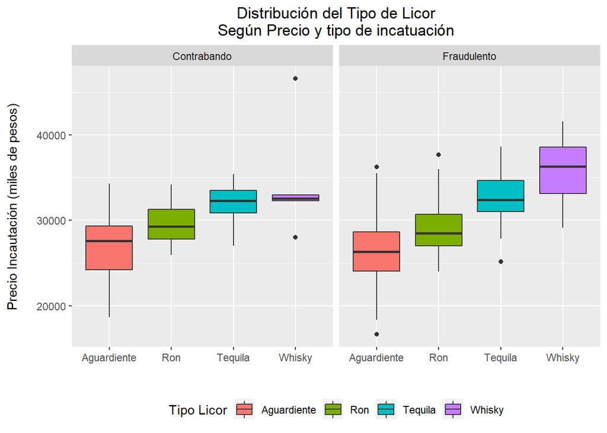

```r
datos %>%
  ggplot(aes(x = TL,y=PI,fill=TL))+ #Construir el gráfico
  geom_boxplot()+ # Agregar capa Boxplot
  facet_wrap(~TI)+ # Dividir por tipo de incautación
  # Títulos de ejes
  ylab("Precio Incautación (miles de pesos)\n")+
  xlab("")+
  labs(fill="Tipo Licor")+
  ggtitle("Distribución del Tipo de Licor\nSegún Precio y tipo de incatuación")+
  # Configuración de ubicación de texto
  theme(legend.position = "bottom",
        plot.title = element_text(h=0.5))
```

El precio de incatuación tiene comportamiento similares entre el tipo de incautación, sin embargo, por tipo de licor muestra algunas diferencias perceptibles a medida que la categoría cambia, la tendencia es a que a mayor calidad de licor, mayor será su precio de venta. Este comportamiento se conservaría para el precio total, puesto que es una combinación lineal con las cantidades estandarizadas.

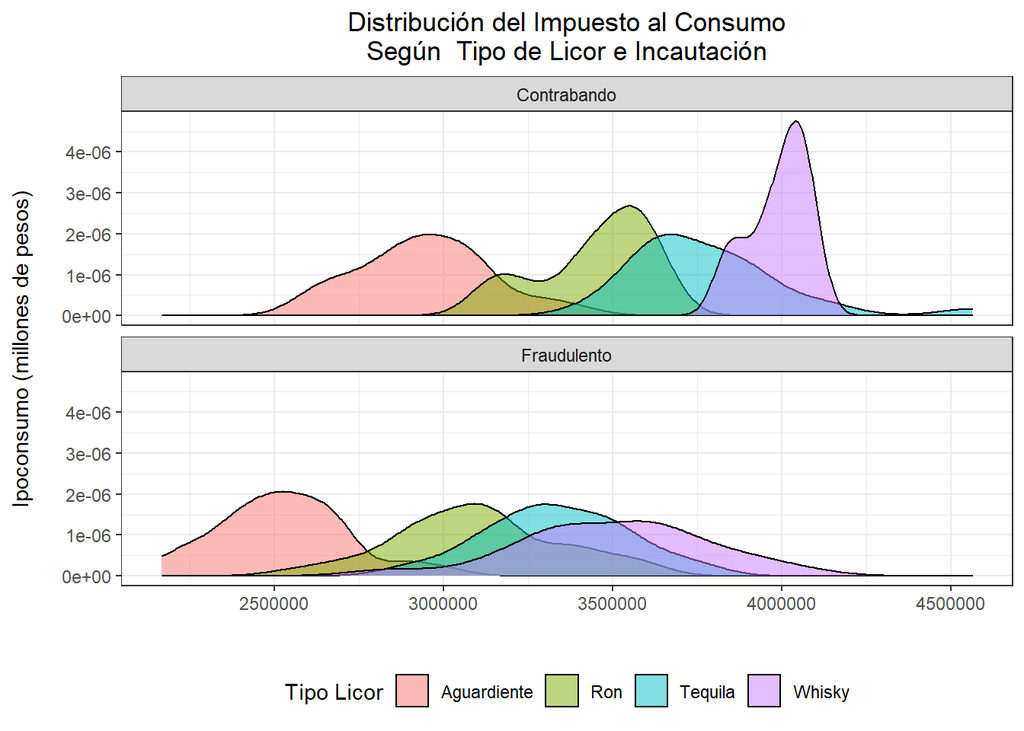

```r
datos %>%
  ggplot(aes(x = IPO,fill=TL))+ #Construir el gráfico
  geom_density(alpha=0.5)+ # Agregar capa densidad
  facet_wrap(~TI,ncol = 1)+ # Dividir por tipo de incautación
  # Títulos de ejes
  ylab("Ipoconsumo (millones de pesos)\n")+
  xlab("")+
  labs(fill="Tipo Licor")+
  ggtitle("Distribución del Impuesto al Consumo\nSegún  Tipo de Licor e Incautación")+
  theme_bw()+ #Fondo blanco
  # Configuración de ubicación de texto
  theme(legend.position = "bottom",
        plot.title = element_text(h=0.5))
```

```r
# Tabla resumen punto 1
datos %>%
  group_by(TI,TL) %>% #Agrupar por Tipo Licor e Incautación
  summarise(TotalInc = sum(CE), #Total incautado
            PromPrecio = mean(PI), #Precio promedio
            PrecTotal = sum(PT), #Precio total
            ImpPerdido = sum(IPO), #Impuesto perdido
            PropGan = mean(1 - IPO/PT)) #Prop Ganancia
```

```
## # A tibble: 8 x 7
## # Groups:   TI [2]
##   TI          TL          TotalInc PromPrecio  PrecTotal ImpPerdido PropGan
##   <chr>       <chr>          <dbl>      <dbl>      <dbl>      <dbl>   <dbl>
## 1 Contrabando Aguardiente    9897.     27060. 267939675. 114809751.   0.562
## 2 Contrabando Ron            3199.     29771.  95076611.  44792538.   0.527
## 3 Contrabando Tequila        6466.     32001. 206798675.  98284293.   0.523
## 4 Contrabando Whisky         1246.     34462.  42902085.  19942668.   0.522
## 5 Fraudulento Aguardiente   21418.     26584. 569779283. 217262612.   0.609
## 6 Fraudulento Ron            9858.     29153. 286933065. 120862447.   0.574
## 7 Fraudulento Tequila       17497.     32752. 573329303. 233316310.   0.590
## 8 Fraudulento Whisky         5528.     35828. 197950516.  77033075.   0.607
```

De acuerdo con la información anterior, se evidencia una cantidad importante de aprehensiones por parte de la gobernación para el control de venta de bebidas alcoholicas fraudulentes y de contrabando en el Departamento de Antioquia. Aumentar los controles significa desincentivar esta práctica, además afecta las finanzas de los grupos delictivos, ya que el margen de ganancia promedio supera el 50% de la venta.

## Punto 2

2. ¿Qué relación estadística existe entre el ipoconsumo y el precio total por tipo de incautación? ¿Qué significa este resultado?

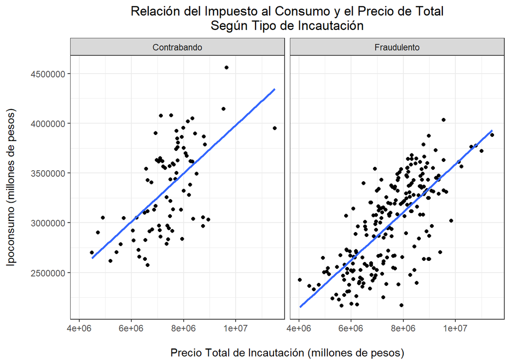

```r
datos %>%
  ggplot(aes(x=PT,y=IPO))+
  geom_point()+ # Agregar puntos
  geom_smooth(se=F,method="lm")+ # Agregar tendencia "lineal"
  # Títulos de ejes
  ylab("Ipoconsumo (millones de pesos)\n")+
  xlab("\nPrecio Total de Incautación (millones de pesos)")+
  ggtitle("Relación del Impuesto al Consumo y el Precio de Total\nSegún Tipo de Incautación")+
  theme_bw()+ #Fondo blanco
  facet_grid(~TI)+ # Dividir por tipo de incautación
  # Configuración de ubicación de texto
  theme(plot.title = element_text(h=0.5))
```

```r
datos %>%
  group_by(TI) %>% #Agrupar por tipo incautación
  summarise(Correlacion = cor(IPO,PT))
```

```
## # A tibble: 2 x 2
##   TI          Correlacion
##   <chr>             <dbl>
## 1 Contrabando       0.595
## 2 Fraudulento       0.712
```

Los resultados sugieren que entre el Ipoconsumo y el Precio Total de incatuación existe una relación que puede ser lineal, además, se precentan correlaciones positivas entre ambas variables. Para el caso de los licores de Contrabando la correlación es moderada y para los Fraudulentos es más fuerte, lo que sugiere que la dependencia del Ipoconsumo del Precio Total de incautación.

## Punto 3

3. La Secretaría de Hacienda quiere analizar la proporción de ganancia que tienen los ilegales frente al ipoconsumo por tipo de licor e incautación. Construya una tabla con los indicadores más representativos y un gráfico que resuma esta intención. ¿Qué se puede interpretar de los resultados?

La proporción de ganancia puede interpretarse como:

$$\%\text{Ganancia} = \left(1 - \frac{\text{Ipoconsumo}}{\text{Precio Total}}\right)\times 100$$

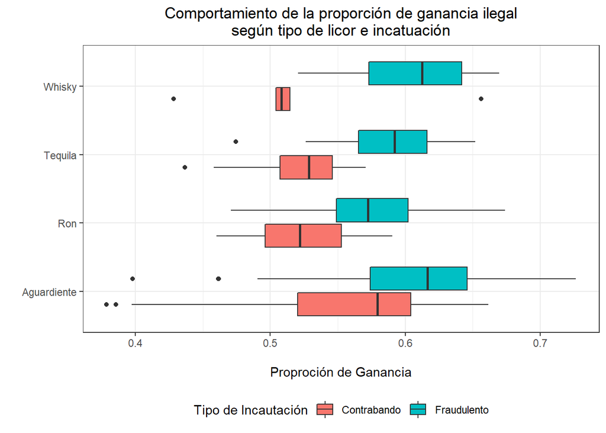

```r
datos %>%
  mutate(PropG = 1 - IPO/PT) %>% # Cálculo de la proporción en base de datos
  ggplot(aes(x=PropG,y=TL,fill=TI))+ # Configuración del gráfico
  geom_boxplot()+ # Agregar capa BoxPlot
  # Títulos del gráfico
  ylab("")+
  xlab("\nProproción de Ganancia")+
  labs(fill="Tipo de Incautación")+
  ggtitle("Comportamiento de la proporción de ganancia ilegal\nsegún tipo de licor e incatuación")+
  theme_bw()+ # Fondo blanco
  # Configuracón títulos y leyenda
  theme(legend.position="bottom",
        plot.title=element_text(h=0.5))
```

De acuerdo con el gráfico, los ilegales ganan más dinero con el licor fraudulento. El negocio es rentable, puesto que los insumos son más económicos y el proceso de fabricación garantiza velocidad, de acuerdo con la gobernación, los ilegales aprovechan las botellas de licor vacías para reemplazar su contenido y así distribuir el licor en todo el departamento.

```r
datos %>%
  mutate(PropG = 1 - IPO/PT) %>% # Cálculo de la proporción en base de datos
  group_by(TI,TL) %>% # Agrupar por tipo de licor e incautación
  summarise(minimo = min(PropG), # Valor mínimo
            mediana = median(PropG), # Mediana
            maximo = max(PropG), # Valor máximo
            RangoInterQ = IQR(PropG), # Rango intercuartil
            CV = RangoInterQ/mediana * 100) # Coeficiente de variación
```

```
## # A tibble: 8 x 7
## # Groups:   TI [2]
##   TI          TL          minimo mediana maximo RangoInterQ    CV
##   <chr>       <chr>        <dbl>   <dbl>  <dbl>       <dbl> <dbl>
## 1 Contrabando Aguardiente  0.378   0.579  0.661      0.0838 14.5
## 2 Contrabando Ron          0.460   0.522  0.590      0.0565 10.8
## 3 Contrabando Tequila      0.437   0.529  0.571      0.0388  7.34
## 4 Contrabando Whisky       0.428   0.508  0.656      0.0104  2.05
## 5 Fraudulento Aguardiente  0.398   0.616  0.726      0.0717 11.6
## 6 Fraudulento Ron          0.471   0.572  0.674      0.0534  9.33
## 7 Fraudulento Tequila      0.475   0.592  0.652      0.0508  8.58
## 8 Fraudulento Whisky       0.520   0.612  0.669      0.0690 11.3
```

Los ilegales encuentran mayor beneficio económico con los licores fraudulentos, en especial con el Whisky y el Aguardiente, este último es el más comercializado en la región y se puede obtener una ganancia máxima hasta del 72.6%. El propender por la venta de licores fraudulentos grarantiza mayor financiación ilegal, pero significa una afectación a la salud preocupante para la población, exponiéndola a diversas enfermedades y afectaciones como la intoxicación, ceguera, trombosis, parálisis y muerte.

## Punto 4

4. Entre los cuatro tipos de licor ¿En cuál es más probable incautar precios de venta entre $25.000 y $35.000? Muestre el proceso del cálculo. ¿Qué significa este resultado?

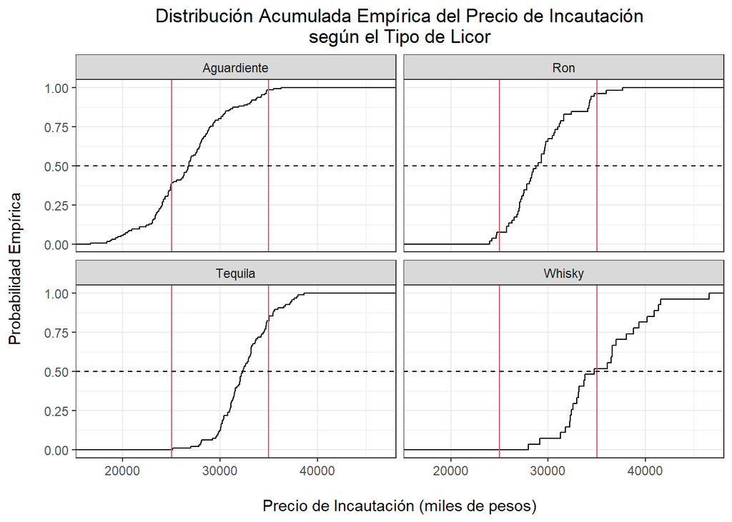

```r
datos %>%
  ggplot(aes(x=PI))+ # Configuración del gráfico
  stat_ecdf()+ # Calcular densidad empírica (ecdf)
  geom_vline(xintercept = c(25000,35000),col=2)+ # Agregar líneas límite en x
  geom_hline(yintercept = 0.5,lty=2)+ # Agregar líneas límite en y
  facet_wrap(~TL)+ # Dividir el gráfico según tipo de licor
  # Títulos del gráfico
  ylab("Probabilidad Empírica\n")+
  xlab("\nPrecio de Incautación (miles de pesos)")+
  ggtitle("Distribución Acumulada Empírica del Precio de Incautación\nsegún el Tipo de Licor")+
  theme_bw()+ # Fondo blanco
  # Disposición del títulos
  theme(plot.title = element_text(h=0.5))
```

Con los datos observados se tienen las densidades acumuladas empíricas, estas sirven para realizar un cálculo aproximado de la probabilidad, lo que se intenta resolver es:

$$P(25000 \leq X_i \leq 35000) = P(X_i \leq 35000) - P(X_i \leq 25000)$$

Donde $X$ es el Precio de Incautación e $i$ representa cada Tipo de Licor.

```r
# La función ecdf sirve para calcular probabilidades empíricas
datos %>%
  group_by(TL) %>%
  summarise(P25 = ecdf(PI)(25000), # P(X <= 25000)
            P35 = ecdf(PI)(35000), # P(X <= 35000)
            Probabilidad = P35 - P25) # P(25000 <= X <= 35000)
```

```
## # A tibble: 4 x 4
##   TL             P25   P35 Probabilidad
##   <chr>        <dbl> <dbl>        <dbl>
## 1 Aguardiente 0.384  0.984        0.6
## 2 Ron         0.0769 0.962        0.885
## 3 Tequila     0      0.823        0.823
## 4 Whisky      0      0.519        0.519
```

Si el precio de incautación oscila entre 25000 y 35000 es más probable que se trate de un Ron, y menos probable un Whisky

Otra opción es asumir que el Precio de Incautación distribuye normal, por lo menos, es necesario verificar gráficamente si los datos tienen forma de campana y es simétrica.

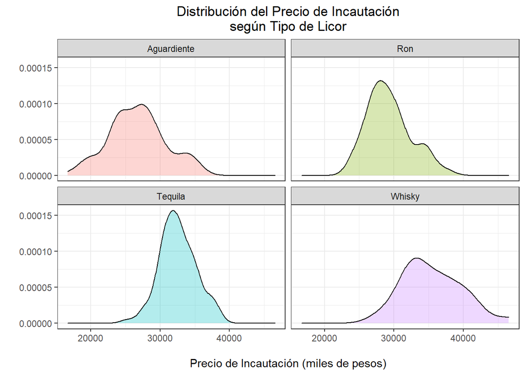

```r
datos %>%
  ggplot(aes(x=PI,fill=TL))+
  geom_density(alpha=0.3)+
  facet_wrap(~TL)+
  ylab("")+
  xlab("\nPrecio de Incautación (miles de pesos)")+
  ggtitle("Distribución del Precio de Incautación\nsegún Tipo de Licor")+
  theme_bw()+
  theme(legend.position = "none",
        plot.title = element_text(h=0.5))
```

De acuerdo con los comportamientos, se ve un poco de simetría y un comportamiento en forma de campana, si asumimos que estas muestras provienen de una distribución normal, entonces con el promedio y desviación estándar se puede estimar los parámetros de la distribución para poder calcular las probabilidades.

$$X_i \sim N(\mu_i,\sigma^2_i)$$

```r
datos %>%
  group_by(TL) %>%
  summarise(mu = mean(PI), # Promedio para estimar mu
            sigma = sd(PI), # Desviación estándar para estimar sigma
            # Probabilidades de una normal, según mu y sigma
            P25 = pnorm(q = 25000,mean = mu,sd = sigma),
            P35 = pnorm(q = 35000,mean = mu,sd = sigma),
            Probabilidad = P35 - P25) # P(25000 <= X <= 35000)
```

```
## # A tibble: 4 x 6
##   TL              mu sigma     P25   P35 Probabilidad
##   <chr>        <dbl> <dbl>   <dbl> <dbl>        <dbl>
## 1 Aguardiente 26733. 4095. 0.336   0.978        0.642
## 2 Ron         29308. 3144. 0.0853  0.965        0.880
## 3 Tequila     32549. 2593. 0.00180 0.828        0.826
## 4 Whisky      35575. 4270. 0.00663 0.446        0.440
```

Las conclusiones son similares al proceso empírico.